# Rstan Introduction

2021/5/6

## RStanの実行

- 基本的に2つのファイルが必要
  - **データ処理のための「.R」ファイル**
  - **RStanを使ってMCMCを実行するときに必要な「.stan」ファイル**

  さらに必要に応じて
  - **データを格納した「.csv」ファイル**

## 「.stan」ファイル

- RStudionでは、「File → New File → Stan File」で作成可能
- 「.stan」ファイルは、主に以下の3つの「ブロック」で構成される
  - `data` ブロック … データとサンプルサイズの情報
  - `parameters` ブロック … 事後分布を得たいパラメータの定義
  - `model` ブロック … モデル（尤度）, 事前分布の定義

## 「.stan」ファイル

- 文法は直感的で分かりやすい（詳しくは後程）
- **注意点**
  - ブロックは中括弧 `{ }` で囲む
  - 行の最後にはセミコロン `;` を打つ
  - コメントアウトはスラッシュ2本 `//`
  - ファイルの最終行には空白行

RStudioでは「Check」でミスがないか確認可能

## 早速書いてみよう

- 以下のビールの売り上げのモデルのパラメータを推定

\[ Sales_i \sim Normal\,(\mu,\sigma^2)\\ \\ (\,\Longleftrightarrow \, Sales_i = \mu + \epsilon_i,\,\, \epsilon_i\sim Normal\,(0,\sigma^2)\,) \]

- それぞれの売り上げの観測値が平均 \(\mu\),分散 \(\sigma^2\) の正規分布に従うという簡単なモデル
- データは「“2-4-1-beer-sales-1.csv”」に格納されている

## 「.stan」を書く

- 「beer_sales.stan」

```stan
data {
  int N;                //サンプルサイズ
  vector[N] sales;      //データ
}

parameters {
  real mu;               //平均のパラメータ
  real<lower=0> sigma;   //標準偏差のパラメータ
}

model {
  for (i in 1:N) {
    sales[i] ~ normal(mu,sigma);
  }     // salesのi番目の値が平均mu,標準偏差sigmaの正規分布から得られた
}       //今回はmu,sigmaの事前分布は指定なし　= (-∞,∞)の一様分布
```

## 「.stan」を書く

- `N` , `sales` については「.R」ファイル内でデータを使って定義
- `mu` , `sigma` はパラメータブロックで定義されている
- 全ての変数・パラメータについて,「型(type)」指定をしなくてはならないことに注意
  - 実数 … `real` (`upper`,`lower`で上下限の指定もできる)
  - 整数 … `int`
  - ベクトル（要素数N） … `vector[N]`
  - 行列（K行J列） … `matrix[K,J]`

## 「.stan」を書く

- `model` ブロックは `for` 文ではなく, ベクトルそのままでも良い

```stan
model {
  sales ~ normal(mu,sigma);
}
```

## 「.R」ファイル; 準備

- まずはデータを読み込む

```r
file_beer_sales_1 <- read.csv("2-4-1-beer-sales-1.csv")
head(file_beer_sales_1)
```

```
##    sales
## 1  87.47
## 2 103.67
## 3  83.29
## 4 131.91
## 5 106.59
## 6  83.59
```

```r
head(file_beer_sales_1$sales)
```

```
## [1]  87.47 103.67  83.29 131.91 106.59  83.59
```

## 「.R」ファイル; 準備

- サンプルサイズを取得

```r
sample_size <- nrow(file_beer_sales_1)
```

- **listで「.Stan」に受け渡すobjectを作る**

```r
data_list <- list(sales = file_beer_sales_1$sales, N = sample_size)
head(data_list$sales)
```

```
## [1]  87.47 103.67  83.29 131.91 106.59  83.59
```

```r
data_list$N
```

```
## [1] 100
```

## 「.R」ファイル; MCMCを実行

```r
library(rstan)
mcmc_result <- stan(
  file = "beer_sales.stan",  #「.stan」ファイル
  data = data_list,          # 受け渡すlist
  seed = 1,　　　　　　　　　  # 乱数のシード
  chains = 4,　　　　　　　　  # チェーン数
  iter = 2000,　　　　　　　   # 1チェーンあたりの乱数の数
  warmup = 1000,　　　　　　  # バーンイン期間の数
  thin = 1,　　　　　　　　　  # 間引き（今回は1なので間引きなし）
)
```

## MCMCの実行結果

```r
print(
  mcmc_result,
  probs=c(0.025,0.5,0.975) #95%信用区間と中央値（MED推定量）
)
```

```
## Inference for Stan model: anon_model.
## 4 chains, each with iter=2000; warmup=1000; thin=1;
## post-warmup draws per chain=1000, total post-warmup draws=4000.
##
##          mean se_mean   sd    2.5%     50%   97.5% n_eff Rhat
## mu     102.18    0.03 1.82   98.57  102.20  105.73  3277    1
## sigma   18.20    0.02 1.29   15.95   18.12   21.00  2858    1
## lp__  -336.44    0.02 0.97 -338.98 -336.12 -335.48  1774    1
##
## Samples were drawn using NUTS(diag_e) at Fri May 07 14:35:39 2021.
## For each parameter, n_eff is a crude measure of effective sample size,
## and Rhat is the potential scale reduction factor on split chains (at
## convergence, Rhat=1).
```

## 古典的な推定値

```r
print(mean(file_beer_sales_1$sales)) #mean
```

```
## [1] 102.1776
```

```r
print(sd(file_beer_sales_1$sales))  #srandard deviation
```

```
## [1] 17.96394
```

## トレースプロット

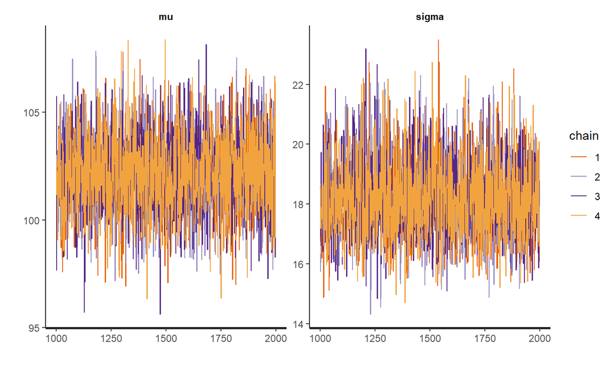

```r
traceplot(mcmc_result)
```

## MCMCサンプルの抽出

```r
mcmc_sample <- rstan::extract(mcmc_result, permuted=FALSE)
# permuted=FALSE で並び順を保持
print(class(mcmc_sample))
```

```
## [1] "array"
```

```r
print(dim(mcmc_sample))
```

```
## [1] 1000    4    3
```

## MCMCサンプルの抽出

```r
print(dimnames(mcmc_sample))
```

```
## $iterations
## NULL
##
## $chains
## [1] "chain:1" "chain:2" "chain:3" "chain:4"
##
## $parameters
## [1] "mu"    "sigma" "lp__"
```

## 代表値の計算

```r
#サンプルのうちmuの情報だけ取り出しベクトルに
mu_mcmc_vec <-as.vector(mcmc_sample[,,"mu"])

#事後中央値(MED)
print(median(mu_mcmc_vec))
```

```
## [1] 102.1961
```

```r
#事後期待値(EAP)
print(mean(mu_mcmc_vec))
```

```
## [1] 102.1772
```

## 代表値の計算

```r
#95％信用区間
print(quantile(mu_mcmc_vec,probs=c(0.025,0.975)))
```

```
##      2.5%     97.5%
##  98.57235 105.73220
```

```r
#事後最高密度値は連続かつ乱数なので求められない
# →　ヒストグラムからカーネル密度推定
```

## 事後分布のプロット

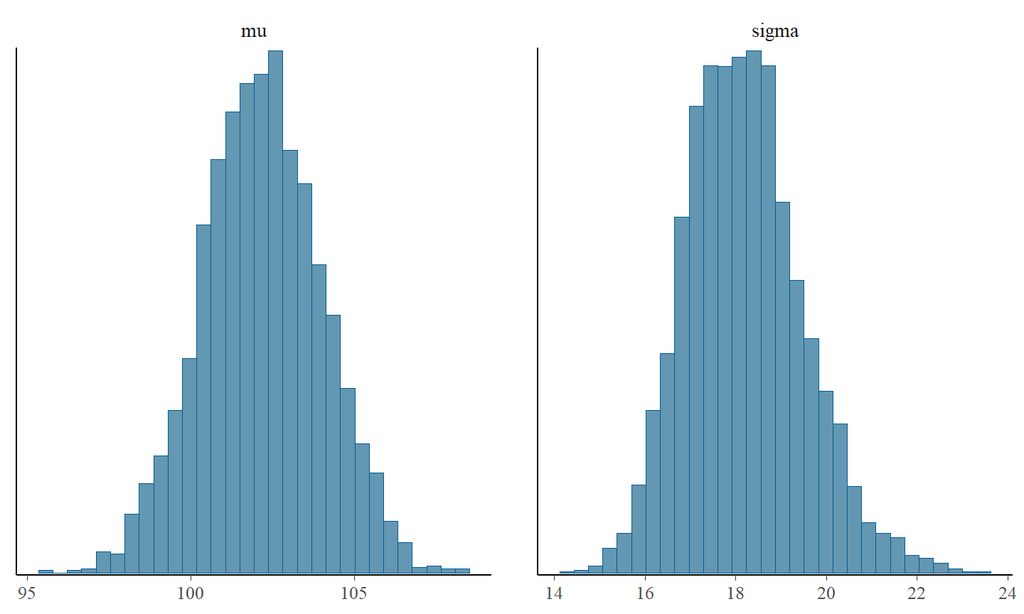

```r
library(bayesplot)

#ヒストグラム
mcmc_hist(mcmc_sample,pars=c("mu","sigma"))
```

## 事後分布のプロット

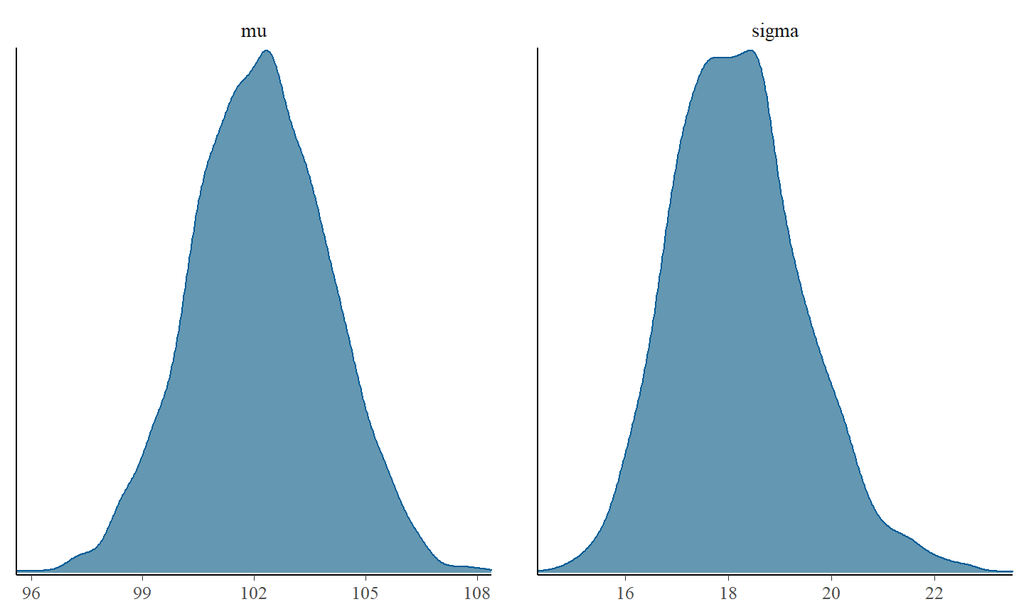

```r
#カーネル密度推定
mcmc_dens(mcmc_sample,pars=c("mu","sigma"))
```

## MCMCサンプルの自己相関の評価

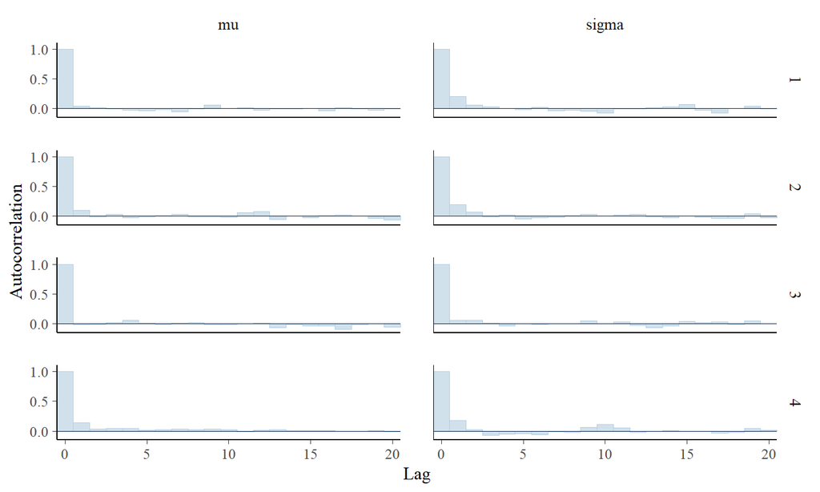

```r
#コレログラム
mcmc_acf_bar(mcmc_sample,pars=c("mu","sigma"))
```

## 参考文献

- 馬場 真哉(2019)「実践Data Scienceシリーズ RとStanではじめる ベイズ統計モデリングによるデータ分析入門」講談社, 第2部第4章,第2部第5章